# Машинное обучение. ВМК МГУ

# Практическое задание 9: Случайные леса и отбор признаков

## Уровень: **Базовый (Base)**

# О формате сдачи

🔷 **При решении ноутбука используйте данный шаблон**

```
✅ Можно добавлять новые ячейки любых типов
❌ Не нужно удалять текстовые ячейки c разметкой частей ноутбука и формулировками заданий
```

🔷 **При оценивании задач учитывается код**

```
✅ Задания, в которых необходим код, обычно помечаются фразами "Your code here"/"Ваш код" и аналогичными
❌ Ответы на вопросы без сопутствующего кода оцениваются в 0 баллов
❌ Наличе работоспособного кода в ноутбуке, если на сказано иного, обязательно
```

🔷 **При оценивании задач учитываются выводы**

```
✅ Задания, в которых необходимы выводы, обычно помечаются фразами Вывод"/"Ответ на вопрос"/"Ваш текст" и аналогичными
✅ Обычно выводы подразумевают под собой текстовый ответ (можно писать markdown, latex).
✅ Сопутствующие изображения, графики, таблички - приветствуются!
❌ При отсутствии выводов задание не засчитается на полный балл
```

**В этом задании вы:**

- Посмотрите, как выращивают случайные леса
- Проверите подвержены ли случайные леса переобучению
- Узнаете базовые методы отбора признаков

**Примерное время выполнения (execution time/время выполнения, если нажать run all) всех ячеек ноутбука при правильной реализации: до 10 минут **

# Подготовка рабочей среды

Сначала установим нужные нам версии библиотек. Мы гарантируем, что в данных версиях задание будет корректно отрабатывать.

После установки нужных версий, **возможно,** нужно перезагрузить среду (runtime), но скорее всего вам это не понадобится

На скачивание файла и установку понадобится не более 5 минут.

**Важно!**

Устанавливать нужные версии нужно каждый раз, когда создается новый рантайм. Например, если вы 2 часа подряд делаете это задание, то подготовить библиотеки достаточно 1 раз. Но если вы, например, начали в понедельник, затем закрыли/выключили ноутбук, то при продолжении в среду, вам нужно будет запустить рантайм заново и следовательно заново установить библиотеки.

**Важно!** Если вы предпочитаете делать практические задания на своем личном ноутбуке, то проверьте, что вы установили рабочее окружение в соответствии с гайдом.pdf)

```python
# !!! Данный блок будет работать только в Google-Colab !!!
! gdown 10k8Hwn9kpK9SpK4IEj4-EaWQZqgYT5-Q
! pip install -r /content/requirements_2024_25_for_colab_small.txt
```

```
Downloading...
From: https://drive.google.com/uc?id=10k8Hwn9kpK9SpK4IEj4-EaWQZqgYT5-Q
To: /content/requirements_2024_25_for_colab_small.txt
100% 375/375 [00:00<00:00, 2.14MB/s]
```

Проверим версию библиотеки:

```python
import catboost
assert(catboost.__version__ == '1.2.7')
```

Теперь можно приступать к выполнению задания! :)

Привет, ребятушки!

Сегодня мы с вами посмотрим на такую вещь, как случайные леса. Мы попытаемся понять принцип их работы, пощупать, исследовать влияние параметров и, самое главное, узнаем, какое свойство случайных лесов оказало сильное влияние на машинное обучение.

Хочу обратить внимание, что в этом задании мы будем работать с регрессорами, однако все сделанные нами выводы верны также и для задач классификации.

**Внимание!** Во всех заданиях в качестве целевой метрики используется MAE (средняя абсолютная ошибка). Значение MAE вычисляется как

$$ MAE = \sum_{i = 1}^N\dfrac{|a(x_i) - y_i|}{N}, $$

где $N$ - число объектов в тестовой выборке, $x_i$ - вектор признаков i-го объекта, $a(x_i)$ - предсказание на i-ом объекте, $y_i$ - значение целевого признака на i-м объекте.

Для вычисления MAE можно использовать встроенную функцию `sklearn.metrics.mean_absolute_error`

Импортируем необходимые библиотеки:

```python
from sklearn.tree import DecisionTreeRegressor, plot_tree
from sklearn.model_selection import train_test_split, GridSearchCV
from sklearn.metrics import mean_absolute_error
from sklearn.datasets import fetch_california_housing
from sklearn.pipeline import Pipeline # Если забыли, загляните в ноутбук Sklearn-knn-normalize-cv
from sklearn.linear_model import LinearRegression
from sklearn.ensemble import RandomForestRegressor

import matplotlib.pyplot as plt
import plotly.express as px
import pandas as pd

#####
# если Вы не различаете предлагаемые цвета, то Вы можете раскомментить строку ниже
# для применения специальной цветовой палитры или аналогичных
# plt.style.use('tableau-colorblind10')
#####

import numpy as np

import time
import os

from itertools import combinations

import warnings
warnings.filterwarnings("ignore", category=FutureWarning)
```

Загрузим датасет со стоимостью недвижимости в Калифорнии, который нам понадобится для первых заданий:

```python
def get_california_dataset():
    """Return the splits of the California housing dataset for training and testing"""
    X, y = fetch_california_housing(return_X_y=True)
    return train_test_split(X, y, random_state=42)

X_train, X_test, y_train, y_test = get_california_dataset()
```

# Случайные леса

Как многие из вас уже знают, теорема Кондорсе о присяжных, гласит, что если у нас имеется некоторое количество различных методов, каждый из которых предсказывает величину лучше, чем случайно, то голосование таких методов работает лучше, чем любой из этих методов по отдельности.

Данная идея отлично ложится на деревья решений. В теории для повышения дисперсии предсказаний каждого отдельного дерева можно ограничивать их глубину. На практике, помимо этого, также хорошо себя показало использование ограниченного набора признаков и данных. Это приводит нас к идее случайных лесов, о которых вы узнали на занятии.

### **Задание 1 [1 балл]**

**Данные**: датасет со стоимостью недвижимости в Калифорнии  
**Метрика качества**: MAE  
**Цели**: В данном задании следует выполнить следующие пункты:

1. Обучить 3 дерева решений, для каждого при инициализации установить `random_state` равный 1, 2 и 3. Ограничивать глубину деревьев не нужно.
2. Получить предсказание для тестовой выборки от каждого регрессора, а также получить `усреднённое` предсказание.
3. Посчитать MAE для каждого из деревьев, полученных в первом пункте, а также для усреднённых предсказаний. Сделать вывод о том, стало лучше или нет.

```python
# your code here
tree_1 = DecisionTreeRegressor(random_state=1)
tree_2 = DecisionTreeRegressor(random_state=2)
tree_3 = DecisionTreeRegressor(random_state=3)

tree_1.fit(X_train, y_train)
tree_2.fit(X_train, y_train)
tree_3.fit(X_train, y_train)
y_pred_1 = tree_1.predict(X_test)
y_pred_2 = tree_2.predict(X_test)
y_pred_3 = tree_3.predict(X_test)
y_pred_avg = (y_pred_1 + y_pred_2 + y_pred_3) / 3

print("MAE (Tree 1):", mean_absolute_error(y_test, y_pred_1))
print("MAE (Tree 2):", mean_absolute_error(y_test, y_pred_2))
print("MAE (Tree 3):", mean_absolute_error(y_test, y_pred_3))
print("MAE (Averaged Predictions):", mean_absolute_error(y_test, y_pred_avg))
```

```
MAE (Tree 1): 0.46331883139534885
MAE (Tree 2): 0.4645068275193799
MAE (Tree 3): 0.46247640503875975
MAE (Averaged Predictions): 0.4542563636950904
```

**Ваш ответ тут:**

Усреднённое предсказание показало меньшую ошибку (MAE), чем каждое дерево в отдельности. Это говорит о том, что ансамблирование (усреднение) улучшило качество модели.

Надеюсь, мы смогли убедиться, что это хоть немного, но работает. Правда, улучшение достаточно маленькое и для прорыва в машинном обучении этого еще недостаточно.

А что влияет на улучшение, которое мы получаем при использовании ансамбля методов? Соответствующая теорема дает достаточно простой ответ: различность методов и ведет к улучшению. Если у нас есть много методов, предсказания которых отличаются незначительно, то их усреднение практически ничего не изменит. Если же у нас есть множество достаточно разных методов, то и их усреднение будет отличаться от предсказаний каждого отдельного метода. Видимо, random_state было недостаточно. Как же нам еще сильнее увеличить различность методов? Ответ вы знаете: использовать случайные признаки и случайную выборку объектов. Это приводит нас к случайным лесам, но с одним уточнением - случайные признаки отбираются не для отдельного дерева, а для конкретной вершины.

### **Задание 1.2 [1 балл]**

**Данные**: датасет со стоимостью недвижимости в Калифорнии  
**Метрика качества**: MAE  
**Цели**: В данном задании следует выполнить следующие пункты:

1. Обучить `RandomForestRegressor`. Для честности следует установить `n_estimators=3`, то есть сделать число деревьев равным 3 (как мы сделали в предыдущем задании). Для однородности также поставьте `random_state = 0`
2. Посчитать MAE полученных предсказаний. Сравнить их с результатами, полученными в предыдущем пункте. Сделайте вывод.

```python
#Your code here
rand_for = RandomForestRegressor(n_estimators=3, random_state=0)
rand_for.fit(X_train, y_train)
y_pred = rand_for.predict(X_test)

print("MAE for random forest:", mean_absolute_error(y_test, y_pred))
```

```
MAE for random forest: 0.3910999521963824
```

**Вывод по результату**:

Использование случайных подвыборок признаков и объектов дало прирост в качестве предсказания ансамбля.

Давайте изучим влияние числа деревьев на результат предсказаний.

### **Задание 1.3 [2 балла]**

**Данные**: датасет со стоимостью недвижимости в Калифорнии  
**Метрика качества**: MAE  
**Цели**: В данном задании следует выполнить следующие пункты:

1. Обучите 10 случайных лесов, установив random_state=42 и замерив время, потраченное на обучение. Для обучаемых лесов, используйте число деревьев (`n_estimators`) из `np.logspace(1, 3, num=10)` (округлите значения вниз до целых чисел). Таким образом мы получим оценку результата для лесов, построенных с различным числом деревьев.
2. Для всех 10 лесов посчитайте MAE на тренировочном и тестовом множествах.
3. Постройте график для отображения зависимости времени обучения от числа деревьев в лесу. Вдоль оси Ox отложите число деревьев, участвующих в обучении. На оси Oy отложите время, потраченное на обучение.
4. Постройте еще один график для отображения зависимости значения MAE от числа деревьев в лесу. Вдоль оси Ox отложите число деревьев, участвующих в обучении. На оси Oy отложите одним цветом значение MAE на тренировочном множестве, другим цветом MAE на тестовом множестве.
5. Проанализируйте результаты и графики, сделайте выводы про время обучения при различном числе деревьев и про качество результатов (в частности - переобучение)

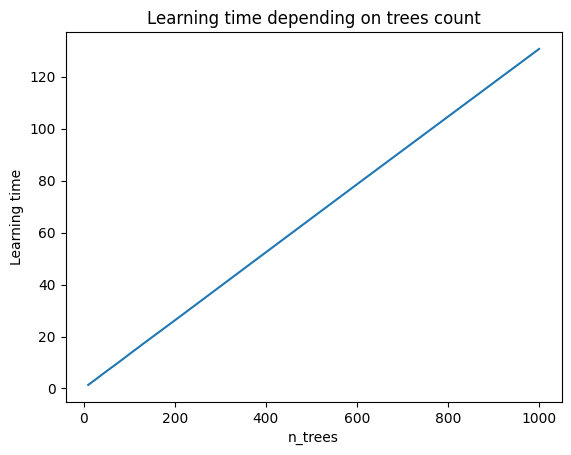

```python
#Your code here
n_trees_list = np.logspace(1, 3, num=10).astype(np.int32)

train_mae_list = []
test_mae_list = []
time_list = []

for n_trees in n_trees_list:
    start_time = time.time()

    rand_for = RandomForestRegressor(n_estimators=n_trees, random_state=42)
    rand_for.fit(X_train, y_train)

    elapsed_time = time.time() - start_time
    time_list.append(elapsed_time)

    y_train_pred = rand_for.predict(X_train)
    train_mae = mean_absolute_error(y_train, y_train_pred)
    train_mae_list.append(train_mae)

    y_test_pred = rand_for.predict(X_test)
    test_mae = mean_absolute_error(y_test, y_test_pred)
    test_mae_list.append(test_mae)

plt.plot(n_trees_list, time_list, label='time')

plt.title('Learning time depending on trees count')
plt.xlabel('n_trees')
plt.ylabel('Learning time')

plt.show()
```

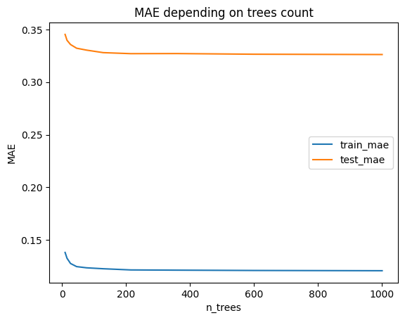

```python
plt.plot(n_trees_list, train_mae_list, label='train_mae')
plt.plot(n_trees_list, test_mae_list, label='test_mae')

plt.title('MAE depending on trees count')
plt.xlabel('n_trees')
plt.ylabel('MAE')
plt.legend()

plt.show()
```

**Вывод по результату**:

**Время обучения:** Время, затрачиваемое на обучение случайного леса, линейно увеличивается с ростом числа деревьев. Это связано с тем, что каждое новое дерево требует дополнительных вычислений.

**Качество предсказаний:** Чем лучше случайный лес подгоняется под обучающую выборку, тем точнее становятся его предсказания на тестовых данных. Это говорит о том, что с увеличением числа деревьев модель становится более устойчивой и точной.

**Отсутствие переобучения:** При наличии достаточно большой и разнообразной обучающей выборки, увеличение числа деревьев не приводит к переобучению. Это объясняется тем, что случайный лес за счёт разнообразия деревьев (благодаря случайному выбору признаков и данных) эффективно избегает переобучения.

Как мы с вами знаем, случайный лес постепенно улучшает качество предсказаний, увеличивая число деревьев в ансамбле. А что если мы уже обучили лес, но хотим `нарастить` его, добавив несколько деревьев? Или если к нам пришли новые данные и мы хотим добавить деревьев, обученных на них, но не удалять деревья, построенные на предыдущих данных? Такой трюк возможен, и для этого следует использовать warm_start. То, как правильно использовать `warm_start` можно глянуть [тут](https://stackoverflow.com/questions/42757892/how-to-use-warm-start/42763502)

### **Задание 1.4 [2 балла]**

**Данные**: датасет со стоимостью недвижимости в Калифорнии  
**Метрика качества**: MAE  
**Цели**: В данном задании следует выполнить следующие пункты:

1. Создайте случайный лес со следующими параметрами: `n_estimators = 100, warm_start = True, random_state=42`
2. Обучите полученный лес, засекая время, потраченное на обучение, и измерив качество предсказания на тесте по MAE
3. Увеличьте число деревьев в лесу. Для этого увеличьте число `regressor.n_estimators` на 100.
4. Воспользуйтесь методом `fit`, чтобы дообучить новые деревья. Не забудьте замерить время и качество!
5. Повторяйте два предыдущих шага до тех пор, пока вы не вырастите лес с 1000 деревьями.
6. Постройте графики зависимости качества и времени обучения от количества деревьев (время считайте отдельно для каждого дообучения, без учета затрат на предыдущие итерации)
7. Проанализируйте результаты и графики, сделайте выводы про время обучения и качество, сравните с результатом из предыдущего пункта

```python
# your code here
rand_for = RandomForestRegressor(n_estimators=100, warm_start=True, random_state=42)

start_time = time.time()
rand_for.fit(X_train, y_train)
elapsed_time = time.time() - start_time

y_pred = rand_for.predict(X_test)
mae = mean_absolute_error(y_test, y_pred)

n_trees_list = [100]
time_list = [elapsed_time]
mae_list = [mae]

for n_trees in range(200, 1001, 100):
    rand_for.n_estimators = n_trees

    start_time = time.time()
    rand_for.fit(X_train, y_train)
    elapsed_time = time.time() - start_time

    y_pred = rand_for.predict(X_test)
    mae = mean_absolute_error(y_test, y_pred)

    n_trees_list.append(n_trees)
    time_list.append(elapsed_time)
    mae_list.append(mae)
```

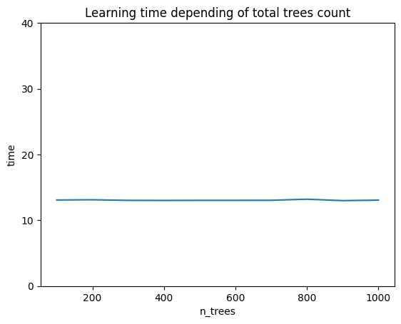

```python
plt.plot(n_trees_list, time_list, label='time')

plt.title('Learning time depending of total trees count')
plt.xlabel('n_trees')
plt.ylabel('time')
plt.yticks(range(0, 41, 10))

plt.show()
```

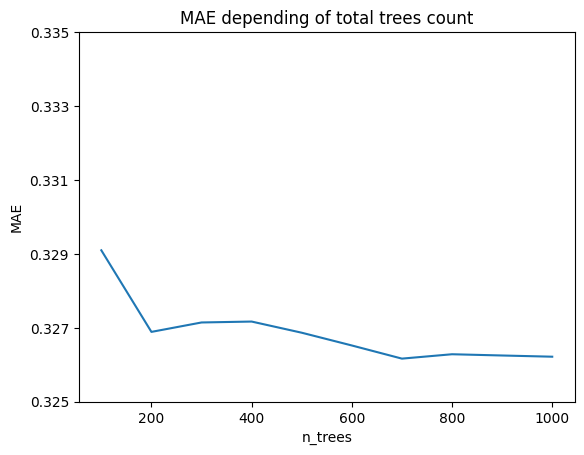

```python
plt.plot(n_trees_list, mae_list, label='MAE')

plt.title('MAE depending of total trees count')
plt.xlabel('n_trees')
plt.ylabel('MAE')
plt.yticks(np.arange(0.3250, 0.336, 0.002))

plt.show()
```

**Вывод по результату**:

**Время дообучения:** В отличие от обучения модели с нуля, при дообучении случайного леса путём добавления новых деревьев время, затрачиваемое на каждую итерацию, остаётся примерно одинаковым. Это связано с тем, что модель не пересоздаётся, а лишь дообучается на новых данных или с новыми деревьями.

**Качество модели:** Дообучение путём увеличения числа деревьев может привести к улучшению итогового качества модели. Это происходит за счёт того, что новые деревья добавляют разнообразие в ансамбль, что способствует повышению точности предсказаний.

# Отбор признаков

Теперь переключимся на несколько иную задачу. Представим, что нам нужно не только обучить какой-то метод, но и выделить наиболее полезные признаки (или, как минимум, удалить шумовые). Как мы можем это сделать? На самом деле, в машинном обучении есть просто огромное количество способов отбора признаков, и сейчас мы познакомимся с самимы популярными из них.

### L1 регуляризация

Как вы уже узнали из лекций, регуляризация помогает делать процесс обучения более робастным. Однако у L1 регуляризации есть один побочный эффект - она также способна занулять наименее информативные признаки. Давайте проверим этот эффект на практике.

### **Задание 2.1 [1 балл]**

**Данные**: датасет со стоимостью недвижимости в Калифорнии  
**Метрика качества**: MAE  
**Цели**: В данном задании следует выполнить следующие пункты:

1. Обучите три линейных классификатора с L1 регуляризацией (`linear_model.Lasso`). Установите коэффициенты регуляризации `alpha` равными `0.1, 0.2 и 0.5.` Перед подачей признаков в Lasso, `нормализуйте признаки` (MinMax или StandardScaler на ваш выбор).
2. Обучите данные классификаторы на обучающем множестве.
3. Замерьте их качество на тесте, а также выведите количество ненулевых коэффициентов. Коэффициенты обученной линейной регрессии можно получить при помощи аттрибута `.coef_`
4. Выведите признаки, которые были занулены. Имена признаков можно найти в fetch_california_housing().feature_names
5. Сделайте выводы о способности LASSO отбирать признаки

```python
# your code here
from sklearn.linear_model import Lasso
from sklearn.preprocessing import StandardScaler

scaler = StandardScaler()
X_train_scaled = scaler.fit_transform(X_train)
X_test_scaled = scaler.transform(X_test)
features = np.array(fetch_california_housing().feature_names)

alphas = [0.1, 0.2, 0.5]

results = []

for alpha in alphas:
    lasso = Lasso(alpha=alpha, random_state=42)
    lasso.fit(X_train_scaled, y_train)

    y_pred = lasso.predict(X_test_scaled)
    mae = mean_absolute_error(y_test, y_pred)

    non_zero_coefs = np.sum(lasso.coef_ != 0)

    zeroed_features = [features[i] for i in range(len(features)) if lasso.coef_[i] == 0]

    results.append({
        'alpha': alpha,
        'mae': mae,
        'non_zero_coefs': non_zero_coefs,
        'zeroed_features': zeroed_features
    })

for result in results:
    print("Alpha:", result['alpha'])
    print("MAE:", result['mae'])
    print("Количество ненулевых коэффициентов:", result['non_zero_coefs'])
    print("Зануленные признаки:", result['zeroed_features'])
```

```
Alpha: 0.1
MAE: 0.6199256011340928
Количество ненулевых коэффициентов: 3
Зануленные признаки: ['AveRooms', 'AveBedrms', 'Population', 'AveOccup', 'Longitude']
Alpha: 0.2
MAE: 0.6568005261632706
Количество ненулевых коэффициентов: 1
Зануленные признаки: ['HouseAge', 'AveRooms', 'AveBedrms', 'Population', 'AveOccup', 'Latitude', 'Longitude']
Alpha: 0.5
MAE: 0.7632241417975693
Количество ненулевых коэффициентов: 1
Зануленные признаки: ['HouseAge', 'AveRooms', 'AveBedrms', 'Population', 'AveOccup', 'Latitude', 'Longitude']
```

**Вывод по результату**:

Как видно, Lasso действительно способен занулять неинформативные признаки, что делает его полезным инструментом для отбора признаков. Однако важно правильно подобрать параметр alpha, так как слишком сильная регуляризация может привести к занулению всех или почти всех признаков. В таком случае модель станет крайне неэффективной и потеряет способность делать точные предсказания.

Отлично! Мы убедились, что при помощи L1 регуляризации можно отбирать наиболее информативные признаки. Такой же трюк можно применять к svm, который может занулить признак, если ни один опорный объект не использует его.

Как мы помним, при помощи линейных классификаторов можно ранжировать признаки по важности, воспользовавшись соответствующими коэффициентами. Но перед этим нужно нормализовать используемые признаки, иначе значения коэффициентов невозможно будет сравнивать между собой.

Мы не зря начали данное задание со случайных лесов. Случайные леса также могут оценивать важность признаков! У каждого обученного леса есть аттрибут `feature_importances_.` Эти оценки рассчитываются на основе уменьшения критерия качества (например, Джини для классификации или среднеквадратичной ошибки для регрессии) при разделении узлов дерева на основе каждого признака. Чем сильнее увеличивается качество при использовании признака - тем он важнее.

Данные значения уже отнормализованы и их можно использовать в явном виде для оценки важности признаков! Давайте воспользуемся этим.

### **Задание 2.2 [1 балл]**

**Данные**: датасет со стоимостью недвижимости в Калифорнии  
**Метрика качества**: MAE  
**Цели**: В данном задании следует выполнить следующие пункты:

1. Обучите один случайный лес, установив`n_estimators=100`.
2. При помощи `rf.feature_importances_` найдите три признака, которые являются наиболее важными, а также три наименее важных признака. Выведите их названия.
3. Обучите обычную линейную регрессию `LinearRegressio`n на всех признаках, а также только на отобранных случайными лесами признаках. Не забывайте, что перед использованием линейной регрессии признаки нужно `отнормализовать`!
4. Сравните качество предсказаний и сделайте вывод о качестве выделенных признаков. Сравните с признаками, выделенными через LASSO.

```python
rand_for = RandomForestRegressor(n_estimators=100, random_state=42)
rand_for.fit(X_train, y_train)

importances = rand_for.feature_importances_

sorted_indices = np.argsort(importances)[::-1]

top_3_features = [features[i] for i in sorted_indices[:3]]

bottom_3_features = [features[i] for i in sorted_indices[-3:]]

print("Три наиболее важных признака:", top_3_features)
print("Три наименее важных признака:", bottom_3_features)

imp_features = [0, 5, 6, 7]

lin_all = Pipeline([
    ('norm', StandardScaler()),
    ('rgr', LinearRegression())
]).fit(X_train, y_train)
lin_all_mae = mean_absolute_error(y_test, lin_all.predict(X_test))

lin_imp = Pipeline([
    ('norm', StandardScaler()),
    ('rgr', LinearRegression())
]).fit(X_train[:, imp_features], y_train)
lin_imp_mae = mean_absolute_error(y_test, lin_imp.predict(X_test[:, imp_features]))

print('LinReg with all features test MAE:', lin_all_mae)
print('LinReg with important features test MAE:', lin_imp_mae)
```

```
Три наиболее важных признака: ['MedInc', 'AveOccup', 'Latitude']
Три наименее важных признака: ['AveRooms', 'Population', 'AveBedrms']
LinReg with all features test MAE: 0.5296964012919462
LinReg with important features test MAE: 0.544897444171256
```

**Вывод по результату**:

Линейная регрессия, обученная на всех признаках, и линейная регрессия, обученная только на наиболее важных признаках (по мнению случайного леса), показывают практически одинаковое качество по MAE. Это говорит о том, что остальные признаки слабо влияют на прогноз и их можно исключить без значительной потери точности.

Как случайный лес, так и Lasso (при правильном выборе параметра alpha) способны эффективно выделять наиболее важные признаки. Однако интересно отметить, что второй по важности признак случайного леса, AveOccup, зануляется Lasso. Это подчеркивает, что разные методы могут по-разному оценивать значимость признаков в зависимости от их внутренних механизмов.

До сих пор мы отбирали признаки по принципу удаления наименее информативных. Однако к данной задаче можно подойти с другого конца - добавлять признаки по 1, выбирая наиболее информативный из тех, что мы еще не использовали. Давайте посмотрим, что мы получим при помощи такой стратегии.

Кратко, данную стратегию можно описать следующим псевдокодом:

1. Инициализировать список выбранных признаков (пустой)
2. Инициализировать список оставшихся признаков (все доступные)
3. Пока выбранное число признаков меньше необходимого:  
   3.1 Для каждого признака из оставшихся:
   - Добавить его к текущему списку выбранных
   - Обучить модель на этих признаках
   - Вычислить ошибку на тестовых данных

   3.2 Добавить признак с наименьшем значением ошибки в пункте 3.1 в список выбранных

   3.3 Удалить его из списка оставшихся
4. Вернуть список лучших признаков

### **Задание 2.3 [2 балл]**

**Данные**: датасет со стоимостью недвижимости в Калифорнии  
**Метрика качества**: MAE  
**Цели**: В данном задании следует выполнить следующие пункты:

1. Реализуйте процесс отбора признаков путем добавление одного наиболее информативного признака. Воспользуйтесь `DecisionTreeRegressor` в качестве базового классификатора.
2. Отберите 3 наиболее важных признака
3. Обучите обычную линейную регрессию на всех признаках, а также только на отобранных признаках. Сравните качество предсказаний и сделайте вывод о качестве выделенных признаков. Сравните с признаками, выделенными в предыдущем задании.

```python
def select_best_features(X_train, X_test, y_train, y_test, max_features=3):
    best_features = []
    remaining_features = list(range(X_train.shape[1]))  # Индексы всех признаков

    for _ in range(max_features):
        best_mae = float('inf')
        best_feature = None

        for feature in remaining_features:
            current_features = best_features + [feature]

            dt = DecisionTreeRegressor(random_state=42)
            dt.fit(X_train[:, current_features], y_train)

            y_pred = dt.predict(X_test[:, current_features])
            mae = mean_absolute_error(y_test, y_pred)

            if mae < best_mae:
                best_mae = mae
                best_feature = feature

        best_features.append(best_feature)
        remaining_features.remove(best_feature)

    return best_features
```

```python
best_features = select_best_features(X_train, X_test, y_train, y_test, max_features=3)

best_feature_names = [features[i] for i in best_features]
print("Три наиболее важных признака:", best_feature_names)
```

```
Три наиболее важных признака: ['Longitude', 'Latitude', 'MedInc']
```

```python
lin_all_my = Pipeline([
    ('norm', StandardScaler()),
    ('rgr', LinearRegression())
]).fit(X_train, y_train)
lin_all_my_mae = mean_absolute_error(y_test, lin_all_my.predict(X_test))

lin_imp_my = Pipeline([
    ('norm', StandardScaler()),
    ('rgr', LinearRegression())
]).fit(X_train[:, best_features], y_train)
lin_imp_my_mae = mean_absolute_error(y_test, lin_imp_my.predict(X_test[:, best_features]))

print('LinReg with all features test MAE:', lin_all_my_mae)
print('LinReg with best features test MAE:', lin_imp_my_mae)
```

```
LinReg with all features test MAE: 0.5296964012919462
LinReg with best features test MAE: 0.5455416989291132
```

**Вывод по результату**:

Признаки, отобранные с использованием описанного алгоритма, отличаются от тех, которые были выбраны случайным лесом (например, признак AveOccup не вошёл в список). Интересно, что самый важный признак по мнению случайного леса, MedInc, был выбран алгоритмом только третьим по очереди.

Тем не менее, качество линейной регрессии, обученной на отобранных признаках, по метрике MAE оказалось таким же, как у модели, обученной на всех признаках или на признаках, выбранных случайным лесом. Это подтверждает, что стратегия пошагового отбора признаков также является эффективной и успешно работает.